# 01_GAMtest

JMH

10/26/2020

# 1 Goal

Test the capability of GAM models to extract a known temperature dependency for decomposition buried in seasonal pattern in decomposition. We will create fake data with a known seasonality and temperature effect, build a GAM model similar in structure used in our manuscript, and evaluate whether or not the GAM can extract the correct seasonality and temperature dependency.

# 2 Load temperature data

We’ll build this up using the real temperature and decomposition data.

```r
decomp <- read.csv("01_combinedDataNew2.csv", row.names = 1) %>%
  mutate(Pdt = as.POSIXct(collection.date, format = "%m/%d/%y"),
         monthN = month,
         monthN = fct_recode(monthN, "1" = "Jan",
                             "2" = "Feb",
                             "3" = "Mar",
                             "4" = "Apr",
                             "5" = "May",
                             "6" = "Jun",
                             "7" = "Jul",
                             "8" = "Aug",
                             "9" = "Sep",
                             "10" = "Oct",
                             "11" = "Nov",
                             "12" = "Dec"),
         monthN = as.numeric(as.character(monthN))) %>%
  #Lick and Stamp have ≥ 1 positive decomposition rate in May and June, respectively
  filter(k < 0 & mesh2 == "fine") %>%
  mutate(lnK = log(abs(k)),
         #Center temperature data
         ArrheniusC = Arrhenius - 1/((15 + 273.15)*0.0000862)) %>%
  group_by(stream, mesh2, monthN) %>%
  # removing one very low decomposition rate
  filter(lnK >-5) %>%
  ungroup() %>%
  select(stream, monthN, rep, ArrheniusC, Temp, lnK) %>%
  droplevels() %>%
  arrange(stream, rep, monthN)
```

Here’s the variation in temperature as a function of month in each stream.

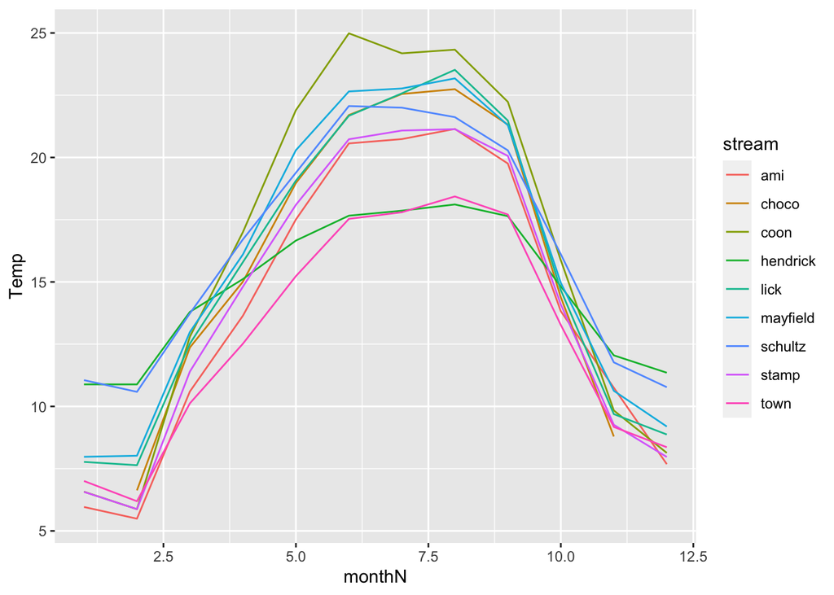

What is the correlation between temperature and month?

```r
cor(decomp$Temp, decomp$monthN, method = "spearman")
```

```
## [1] 0.2119002
```

The correlation is pretty low due to the non-linearity. During most months prior to September, we have > 5°C variation in temperature among streams.

# 3 Generate fake data

Let’s assume that k has two components: (1) a temperature dependency and (2) a seasonality which is everything else that influences k that varies with month (e.g., chl a, shredding macroinvertebrates, nutrients, ect.). Here’s our approach for faking the k data with these components:

- Create decomposition data with a temperature dependency similar to what we observed with the GAM models.
- Create decomposition data with two seasonality responses for k: (1) similar to the observed temperature X month relationship, (2) a much more complicated seasonality pattern as a worst case scenario.

We’ll create each of these subcomponents and then sum them to calculate $k_{tot}$.

```r
FakeK <- decomp %>%
  # a column with some random variation
  mutate(ranNum = rnorm(dim(decomp)[1], mean = 0, sd = 0.02),
         # the temperature effect - this is the model from the most likely GAM
         TempEffect = (-4.35 + -0.08*ArrheniusC)+ranNum,
         # the seasonal effect
         # Intercept adjusted to make range same as temp effect
         SeasEffect1 = ((-8.5 + 0.2*monthN + -0.015*monthN^2) +ranNum)*0.55, #0.55 to make range smaller
         SeasEffect2 = -4.25 + sin(monthN)*0.1 + ranNum,
         # add them together (intercept incorporated into temp effect)
         kTot1 = TempEffect + SeasEffect1,
         kTot2 = TempEffect + SeasEffect2)
```

# 4 Examine fake data

## 4.1 Temperature

By design, there’s the same temperature effect in both models: k = 0.08. Same as from our GAMS.

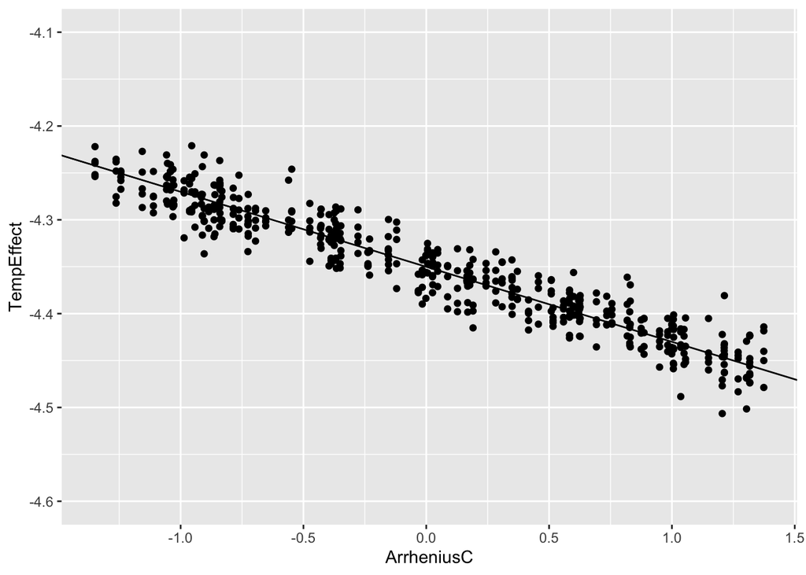

## 4.2 Seasonality

Seasonality of K versus temperature and month. This is $K_{tot}$.

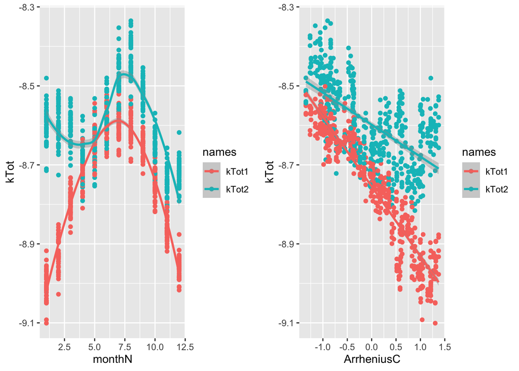

## 4.3 Related to real data?

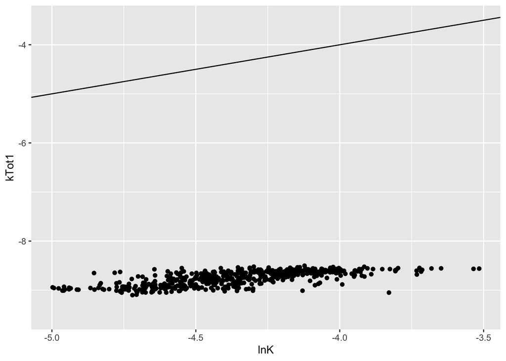

# 5 Models

## 5.1 Seasonality 1

### 5.1.1 GAM

Best fine-mesh gam model - it works! The GAM returns an AE close to what we put in and a seasonality similar to what we created.

```r
Bgam1 <- gamm(kTot1 ~ ArrheniusC + s(monthN, by = Only2Groups, bs = "cc", k = 12)+ s(stream, bs="re"),
                      correlation = cor1a, data = FakeK)
```

```r
summary(Bgam1$gam)
```

```
##
## Family: gaussian
## Link function: identity
##
## Formula:
## kTot1 ~ ArrheniusC + s(monthN, by = Only2Groups, bs = "cc", k = 12) +
##     s(stream, bs = "re")
##
## Parametric coefficients:
##              Estimate Std. Error  t value Pr(>|t|)
## (Intercept) -8.754939   0.001382 -6336.97   <2e-16 ***
## ArrheniusC  -0.081454   0.006708   -12.14   <2e-16 ***
## ---
## Signif. codes:  0 '***' 0.001 '**' 0.01 '*' 0.05 '.' 0.1 ' ' 1
##
## Approximate significance of smooth terms:
##                                edf Ref.df      F p-value
## s(monthN):Only2GroupsSpring 9.0431     10 58.701  <2e-16 ***
## s(monthN):Only2GroupsSummer 9.1191     10 45.727  <2e-16 ***
## s(stream)                   0.6924      8  0.116   0.226
## ---
## Signif. codes:  0 '***' 0.001 '**' 0.01 '*' 0.05 '.' 0.1 ' ' 1
##
## R-sq.(adj) =  0.956
##   Scale est. = 0.00092278  n = 505
```

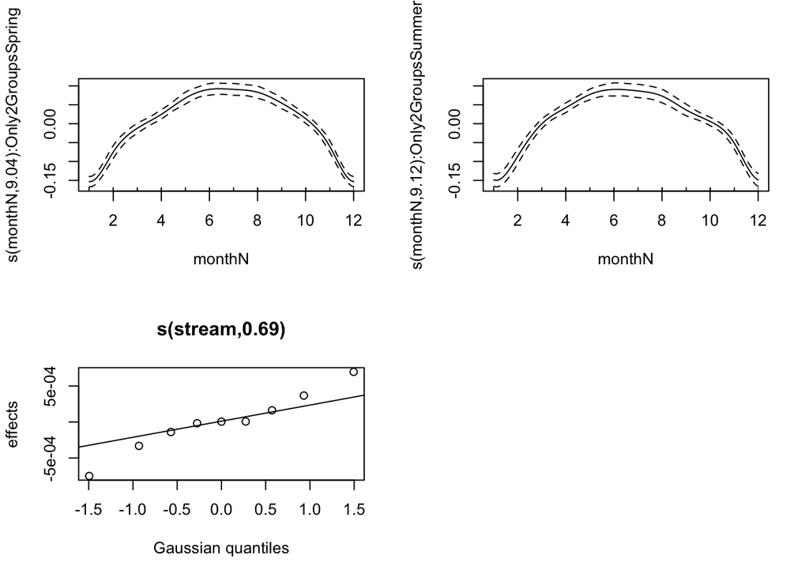

```r
Blme1 <- lme(kTot1 ~ ArrheniusC, random = ~1|stream, data = FakeK)
```

```r
summary(Blme1)
```

```
## Linear mixed-effects model fit by REML
##  Data: FakeK
##         AIC       BIC   logLik
##   -1594.643 -1577.761 801.3215
##
## Random effects:
##  Formula: ~1 | stream
##         (Intercept)   Residual
## StdDev:  0.01510301 0.04789137
##
## Fixed effects: kTot1 ~ ArrheniusC
##                 Value   Std.Error  DF    t-value p-value
## (Intercept) -8.754454 0.005468469 495 -1600.8965       0
## ArrheniusC  -0.179564 0.002804148 495   -64.0351       0
##  Correlation:
##            (Intr)
## ArrheniusC -0.001
##
## Standardized Within-Group Residuals:
##         Min          Q1         Med          Q3         Max
## -3.14903943 -0.65566996  0.08528261  0.69453753  2.38465685
##
## Number of Observations: 505
## Number of Groups: 9
```

## 5.2 Seasonality 2

### 5.2.1 GAM

```r
Bgam2 <- gamm(kTot2 ~ ArrheniusC + s(monthN, by = Only2Groups, bs = "cc", k = 12)+ s(stream, bs="re"),
                      correlation = cor1a, data = FakeK)
```

```r
summary(Bgam2$gam)
```

```
##
## Family: gaussian
## Link function: identity
##
## Formula:
## kTot2 ~ ArrheniusC + s(monthN, by = Only2Groups, bs = "cc", k = 12) +
##     s(stream, bs = "re")
##
## Parametric coefficients:
##              Estimate Std. Error   t value Pr(>|t|)
## (Intercept) -8.598404   0.002778 -3094.926  < 2e-16 ***
## ArrheniusC  -0.043928   0.011756    -3.737 0.000209 ***
## ---
## Signif. codes:  0 '***' 0.001 '**' 0.01 '*' 0.05 '.' 0.1 ' ' 1
##
## Approximate significance of smooth terms:
##                               edf Ref.df      F p-value
## s(monthN):Only2GroupsSpring 8.899     10 50.691  <2e-16 ***
## s(monthN):Only2GroupsSummer 8.850     10 51.544  <2e-16 ***
## s(stream)                   3.338      8  0.769  0.0698 .
## ---
## Signif. codes:  0 '***' 0.001 '**' 0.01 '*' 0.05 '.' 0.1 ' ' 1
##
## R-sq.(adj) =  0.793
##   Scale est. = 0.0021311  n = 505
```

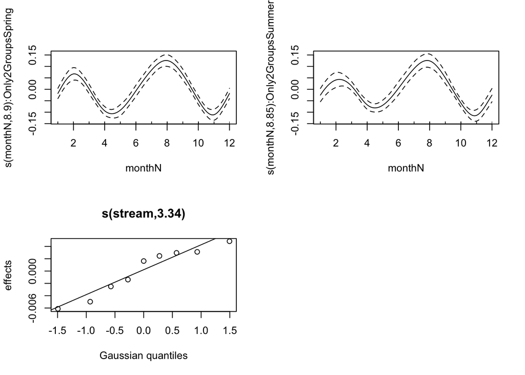

### 5.2.2 LME

In this case, the lme model gets us closer to the TRUE AE eventhough it doesn’t account for the seasonality.

```r
Blme2 <- lme(kTot2 ~ ArrheniusC, random = ~1|stream, data = FakeK)
```

```r
summary(Blme2)
```

```
## Linear mixed-effects model fit by REML
##  Data: FakeK
##         AIC       BIC   logLik
##   -1093.757 -1076.874 550.8784
##
## Random effects:
##  Formula: ~1 | stream
##          (Intercept)   Residual
## StdDev: 1.194652e-06 0.07997904
##
## Fixed effects: kTot2 ~ ArrheniusC
##                 Value   Std.Error  DF    t-value p-value
## (Intercept) -8.598170 0.003559116 495 -2415.8159       0
## ArrheniusC  -0.081045 0.004596094 495   -17.6335       0
##  Correlation:
##            (Intr)
## ArrheniusC -0.007
##
## Standardized Within-Group Residuals:
##         Min          Q1         Med          Q3         Max
## -2.28021931 -0.81932131  0.02705196  0.77818185  2.70330374
##
## Number of Observations: 505
## Number of Groups: 9
```